# R Notebook

# R murder mystery

A short murder mystery game which can be solved by using various functions and packages associated to tidyverse.

The initial question would be this:

> You vaguely remember that a **murder** occurred sometime on **Jan.15, 2018** and that it took place in **SQL City** (we can change SQL City to R city or something else). Find the killer.

The table structure is like this:

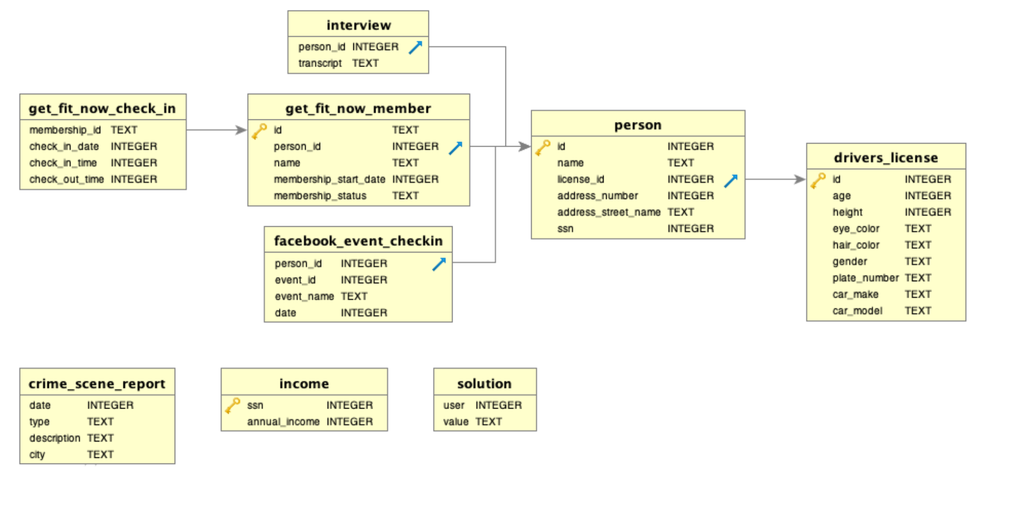

## Task 1 - Read in data

Data is read in using readr or zoom. One could perhaps also require it to be read in using functionals and some regex to name it. If regex is to complicated, they can get the actual expression, so that they don’t need to create it themselves.

Alternatively, we can provide the actual function for participants.

> **MacOS/Unix regular expression:** [^/:\*?\<\>\|\\r\\n]+?(?=\\.)

> **Windows regular expression:** [^\\\\:\*?\<\>\|\\r\\n]+?(?=\\.)

There is one function that are not explained in the course needed (assign), which is a bit of a difficult function to explain in a short period of time. One actually needs to specify “,” as, vroom cant guess the interview.csv.

#### Step 1: Create function to read file

```r
read_table <- function(file_path) {
    # Extract table name
    regex <- "[^/:*?<>|\r\n]+?(?=\\.)"
    name <- stringr::str_extract(file_path, regex)

    # Read table
    table <- vroom::vroom(file_path,
                          show_col_types = FALSE,
                          delim = ",")

    # Return
    assign(name, table, envir = .GlobalEnv)
}
read_table("data/interview.csv")
```

#### Step 2: Read the files

Read using map() and dir_ls().

```r
files <- fs::dir_ls(here::here("data/"))

purrr::map(files, read_table)
```

```
$`/Users/andersaskeland/GitHub/R-murder-mystery/data/crime_scene_report.csv`
```

| date | type | description | city |
| --- | --- | --- | --- |
| 20180115 | robbery | A Man Dressed as Spider-Man Is on a Robbery Spree | NYC |
| 20180115 | murder | Life? Dont talk to me about life. | Albany |
| 20180115 | murder | Mama, I killed a man, put a gun against his head... | Reno |
| 20180215 | murder | REDACTED REDACTED REDACTED | SQL City |
| 20180215 | murder | Someone killed the guard! He took an arrow to the knee! | SQL City |
| 20180115 | theft | Big Bully stole my lunch money! | Chicago |
| 20180115 | fraud | Lorem ipsum dolor sit amet, consectetur adipiscing elit, sed do\n eiusmod tempor incididunt ut labore et dolore magna aliqua. | Seattle |
| 20170712 | theft | A lone hunter stalks the night, firing arrows into the Darkness.\n There is no hiding, no escape. In the distance, the beast\n falters, tethered to the void. The killing blow comes without\n hesitatio… | SQL City |
| 20170820 | arson | Wield the Hammer of Sol with honor, Titan, it is a thing of\n legend, both past and future. | SQL City |
| 20171110 | robbery | The Gjallarhorn shoulder-mounted rocket system was forged from\n the armor of Guardians who fell at the Twilight Gap. Gifted\n to the survivors of that terrible battle, the Gjallarhorn\n is seen as a … | SQL City |

[output cut: 990 more lines]

```
$`/Users/andersaskeland/GitHub/R-murder-mystery/data/drivers_license.csv`
```

| id | age | height | eye_color | hair_color | gender | plate_number | car_make | car_model |
| --- | --- | --- | --- | --- | --- | --- | --- | --- |
| 100280 | 72 | 57 | brown | red | male | P24L4U | Acura | MDX |
| 100460 | 63 | 72 | brown | brown | female | XF02T6 | Cadillac | SRX |
| 101029 | 62 | 74 | green | green | female | VKY5KR | Scion | xB |
| 101198 | 43 | 54 | amber | brown | female | Y5NZ08 | Nissan | Rogue |
| 101255 | 18 | 79 | blue | grey | female | 5162Z1 | Lexus | GS |
| 101494 | 48 | 55 | blue | red | female | 81X1N7 | Kia | Sportage |
| 101568 | 53 | 78 | brown | blue | male | SJ57LL | Saab | 9-5 |
| 101586 | 57 | 70 | amber | brown | male | 31U1KE | Jaguar | XK |
| 101611 | 40 | 65 | blue | white | female | 5O8VW7 | GMC | Sierra Denali |
| 101613 | 81 | 58 | brown | grey | female | 5PCQB5 | GMC | Sierra 2500 |

[output cut: 990 more lines]

```
$`/Users/andersaskeland/GitHub/R-murder-mystery/data/facebook_event_checkin.csv`
```

| person_id | event_id | event_name | date |
| --- | --- | --- | --- |
| 28508 | 5880 | Nudists are people who wear one-button suits.\n | 20170913 |
| 63713 | 3865 | but that's because it's the best book on anything for the layman.\n | 20171009 |
| 63713 | 3999 | If Murphy's Law can go wrong, it will.\n | 20170502 |
| 63713 | 6436 | Old programmers never die. They just branch to a new address.\n | 20170926 |
| 82998 | 4470 | Help a swallow land at Capistrano.\n | 20171022 |
| 82998 | 6186 | Good day to let down old friends who need help.\n | 20170921 |
| 82998 | 7364 | Among economists, the real world is often a special case.\n | 20170320 |
| 31811 | 8542 | -- Herbert Prochnow\n | 20171203 |
| 31811 | 4387 | The Pig, if I am not mistaken,\n | 20180106 |
| 61201 | 9621 | responsibility at the other.\n | 20180418 |

[output cut: 990 more lines]

```
$`/Users/andersaskeland/GitHub/R-murder-mystery/data/get_fit_now_check_in.csv`
```

| membership_id | check_in_date | check_in_time | check_out_time |
| --- | --- | --- | --- |
| NL318 | 20180212 | 329 | 365 |
| NL318 | 20170811 | 469 | 920 |
| NL318 | 20180429 | 506 | 554 |
| NL318 | 20180128 | 124 | 759 |
| NL318 | 20171027 | 418 | 1019 |
| NL318 | 20171018 | 608 | 1074 |
| NL318 | 20171127 | 850 | 954 |
| NL318 | 20170627 | 591 | 715 |
| NL318 | 20180114 | 777 | 813 |
| NL318 | 20171107 | 148 | 460 |

[output cut: 990 more lines]

```
$`/Users/andersaskeland/GitHub/R-murder-mystery/data/get_fit_now_member.csv`
```

| id | person_id | name | membership_start_date | membership_status |
| --- | --- | --- | --- | --- |
| NL318 | 65076 | Everette Koepke | 20170926 | gold |
| AOE21 | 39426 | Noe Locascio | 20171005 | regular |
| 2PN28 | 63823 | Jeromy Heitschmidt | 20180215 | silver |
| 0YJ24 | 80651 | Waneta Wellard | 20171206 | gold |
| 3A08L | 32858 | Mei Bianchin | 20170401 | silver |
| 6W6I2 | 69510 | Paris Accurso | 20170613 | regular |
| 5Y28Y | 15218 | Millicent Yessios | 20180205 | gold |
| 156A7 | 79701 | Marcelino Leard | 20180428 | silver |
| A5N3S | 24541 | Mary Cameron | 20170501 | gold |
| X0643 | 15247 | Shondra Ledlow | 20170521 | silver |

[output cut: 174 more lines]

```
$`/Users/andersaskeland/GitHub/R-murder-mystery/data/income.csv`
```

| ssn | annual_income |
| --- | --- |
| 100009868 | 52200 |
| 100169584 | 64500 |
| 100300433 | 74400 |
| 100355733 | 35900 |
| 100366269 | 73000 |
| 100593316 | 16100 |
| 100626193 | 10800 |
| 100739881 | 53800 |
| 100749089 | 61200 |
| 100958115 | 51200 |

[output cut: 990 more lines]

```
$`/Users/andersaskeland/GitHub/R-murder-mystery/data/interview.csv`
```

| person_id | transcript |
| --- | --- |
| 28508 | ‘I deny it!’ said the March Hare.\n |
| 63713 | \n |
| 86208 | way, and the whole party swam to the shore.\n |
| 35267 | lessons in here? Why, there’s hardly room for YOU, and no room at all\n |
| 33856 | \n |
| 82799 | \n |
| 66493 | would be offended again.\n |
| 46263 | ‘So he did, so he did,’ said the Gryphon, sighing in his turn; and both\n |
| 54263 | very glad that it was over at last: ‘and I do so like that curious song\n |
| 62764 | come to the end: then stop.’\n |

[output cut: 990 more lines]

```
$`/Users/andersaskeland/GitHub/R-murder-mystery/data/person.csv`
```

| id | name | license_id | address_number | address_street_name | ssn |
| --- | --- | --- | --- | --- | --- |
| 10000 | Christoper Peteuil | 993845 | 624 | Bankhall Ave | 747714076 |
| 10007 | Kourtney Calderwood | 861794 | 2791 | Gustavus Blvd | 477972044 |
| 10010 | Muoi Cary | 385336 | 741 | Northwestern Dr | 828638512 |
| 10016 | Era Moselle | 431897 | 1987 | Wood Glade St | 614621061 |
| 10025 | Trena Hornby | 550890 | 276 | Daws Hill Way | 223877684 |
| 10027 | Antione Godbolt | 439509 | 2431 | Zelham Dr | 491650087 |
| 10034 | Kyra Buen | 920494 | 1873 | Sleigh Dr | 332497972 |
| 10039 | Francesco Agundez | 278151 | 736 | Buswell Dr | 861079251 |
| 10095 | Leslie Thate | 729987 | 2772 | Camellia Park Circle | 127944356 |
| 10122 | Alva Conkel | 779002 | 116 | Diversey Circle | 148521773 |

[output cut: 990 more lines]

```
NA
```

## Task 2 - Crime scene report

First one would need to look at the crime scene report for that given day.

#### Step 1 - View possible columns in Crime scene report

```r
# View columns
colnames(crime_scene_report)
```

```
[1] "date"        "type"        "description" "city"
```

#### Step 2 - Figure out how the date parameter is coded

```r
map(crime_scene_report, class)
```

```
$date
[1] "numeric"

$type
[1] "character"

$description
[1] "character"

$city
[1] "character"
```

#### Step 3 - Find descriptions for the day of the murder

```r
crime_scene_report %>%
    dplyr::filter(date == "20180115" &
                      type == "murder" &
                      city == "SQL City") %>%
    dplyr::select(description)
```

| description |
| --- |
| Security footage shows that there were 2 witnesses. The first witness lives at the last house on "Northwestern Dr". The second witness, named Annabel, lives somewhere on "Franklin Ave". |

The following information is found doing this:

> “Security footage shows that there were 2 witnesses. The first witness lives at the last house on”Northwestern Dr”. The second witness, named Annabel, lives somewhere on “Franklin Ave”.”

#### Step 4 - Find the witnesses

One needs to look in the person table to find street names.

**4.1. First witness**

One knows that the first witness lives at the last house in “Northwestern Dr”.

```r
person %>%
    dplyr::filter(address_street_name == "Northwestern Dr") %>%
    dplyr::arrange(desc(address_number))
```

| id | name | license_id | address_number | address_street_name | ssn |
| --- | --- | --- | --- | --- | --- |
| 14887 | Morty Schapiro | 118009 | 4919 | Northwestern Dr | 111564949 |
| 17729 | Lasonya Wildey | 439686 | 3824 | Northwestern Dr | 917817122 |
| 53890 | Sophie Tiberio | 957671 | 3755 | Northwestern Dr | 442830147 |
| 73368 | Torie Thalmann | 773862 | 3697 | Northwestern Dr | 341559436 |
| 96595 | Coretta Cubie | 303645 | 3631 | Northwestern Dr | 378403829 |
| 19420 | Cody Schiel | 890431 | 3524 | Northwestern Dr | 947110049 |
| 93509 | Emmitt Aceuedo | 916706 | 3491 | Northwestern Dr | 979073160 |
| 87456 | Leonora Wolfsberger | 215868 | 3483 | Northwestern Dr | 565203106 |
| 36378 | Freddie Ellzey | 267882 | 3449 | Northwestern Dr | 474117596 |
| 53076 | Boris Bijou | 664914 | 3327 | Northwestern Dr | 401191868 |

[output cut: 40 more lines]

The witness must be “Morty Schapiro” with a ID of 14887.

#### **4.2. Second witness**

This one needs some regex (str_detect). Might be too difficult?

```r
person %>%
    dplyr::filter(address_street_name == "Franklin Ave" &
                     stringr::str_detect(name, "Annabel"))
```

| id | name | license_id | address_number | address_street_name | ssn |
| --- | --- | --- | --- | --- | --- |
| 16371 | Annabel Miller | 490173 | 103 | Franklin Ave | 318771143 |

```r
NA
```

The second witness is Annabel Miller with an ID of 16371.

#### Step 5 - Find witness statements (Interviews)

First we need to look at the interview table to figure out which columns/variables it contains.

```r
glimpse(interview)
```

```
Rows: 4,991
Columns: 2
$ person_id  <dbl> 28508, 63713, 86208, 35267, 33856, 82799, 66493, 46263, 54263, 62764…
$ transcript <chr> "‘I deny it!’ said the March Hare.\n", "\n", "way, and the whole par…
```

We have person id from the person table. We can use this to extract the data we want.

**Witness 1 - Annabel Miller**

```r
interview %>%
    dplyr::filter(person_id == 16371) %>%
    dplyr::select(transcript)
```

| transcript |
| --- |
| I saw the murder happen, and I recognized the killer from my gym when I was working out last week on January the 9th. |

The transcript is as follows:

> I saw the murder happen, and I recognized the killer from my gym when I was working out last week on January the 9th.

We need to figure out who exercised on January the 9th.

**Witness 2 - Morty**

```r
interview %>%
    dplyr::filter(person_id == 14887) %>%
    dplyr::select(transcript)
```

| transcript |
| --- |
| I heard a gunshot and then saw a man run out. He had a "Get Fit Now Gym" bag. The membership number on the bag started with "48Z". Only gold members have those bags. The man got into a car with a plat… |

His interview said the following:

> I heard a gunshot and then saw a man run out. He had a “Get Fit Now Gym” bag. The membership number on the bag started with “48Z”. Only gold members have those bags. The man got into a car with a plate that included “H42W”.

This does not tell us much besides the fact that he was at Get fit now and a membership number. We might be able to use this afterwards.

#### Step 6 - Who was working out?

This next part might be tricky. One needs to combine the “get_fit_now_check_in” to be able to find out who worked out at that specific time.

From the initial data layout we know that “id” from “get_fit_now_member” is the same as “membership_id” from “get_fit_now_check_in”. We need to do some column binding to figure out who was exercising at the time we are interested in.

We need to combine the “get_fit_now_check_in” and “get_fit_now_member”.

```r
fitness_person_checkin_combined <- dplyr::left_join(x = get_fit_now_member, y = get_fit_now_check_in, by = c("id" = "membership_id"))
```

Next we need to look what happens on January the 9th.

```r
fitness_person_checkin_combined %>%
    dplyr::filter(check_in_date == 20180109 &
                      stringr::str_detect(id, "48Z"))
```

| id | person_id | name | membership_start_date | membership_status | check_in_date | check_in_time | check_out_time |
| --- | --- | --- | --- | --- | --- | --- | --- |
| 48Z7A | 28819 | Joe Germuska | 20160305 | gold | 20180109 | 1600 | 1730 |
| 48Z55 | 67318 | Jeremy Bowers | 20160101 | gold | 20180109 | 1530 | 1700 |

There are 2 possible people checked in at the same time as Annabel saw the killer. One of them must be the killer.

We need to investigate person_id 28819, 67318.

#### Step 7 - Car lookup

We want to see which cars matches the description of Morty.

First we must find the licence plate ID of the two persons.

```r
person %>%
    dplyr::filter(id %in% c(28819, 67318)) %>%
    dplyr::select(c(name, license_id))
```

| name | license_id |
| --- | --- |
| Joe Germuska | 173289 |
| Jeremy Bowers | 423327 |

Now we need to find the car and make of the two people.

```r
drivers_license %>%
    dplyr::filter(id %in% c(173289, 423327))
```

| id | age | height | eye_color | hair_color | gender | plate_number | car_make | car_model |
| --- | --- | --- | --- | --- | --- | --- | --- | --- |
| 423327 | 30 | 70 | brown | brown | male | 0H42W2 | Chevrolet | Spark LS |

We could also combine the two columns to better be able to see whos who.

```r
dplyr::left_join(x = person, y = drivers_license, by = c("license_id" = "id")) %>%
    dplyr::filter(license_id %in% c(173289, 423327) &
                      stringr::str_detect(plate_number, "H42W"))
```

| id | name | license_id | address_number | address_street_name | ssn | age | height | eye_color | hair_color | gender | plate_number | car_make | car_model |
| --- | --- | --- | --- | --- | --- | --- | --- | --- | --- | --- | --- | --- | --- |
| 67318 | Jeremy Bowers | 423327 | 530 | Washington Pl, Apt 3A | 871539279 | 30 | 70 | brown | brown | male | 0H42W2 | Chevrolet | Spark LS |

The killer is Jeremy Bowers.

#### The end

This could be the end. There is however, a witness transcript from Jeremy Bowers that indicates that he is not the killer, potentially extending the exercise.

Another possibility to add complexity could be to pivot a table, so that the participants needs to pivot it back.